# Introduction to SC19087

## A-B-O blood type problem

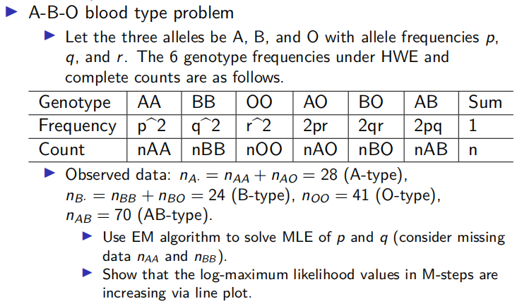

## Answer

The iteration is after calculation.

Write the $E_{\hat p_0,\hat q_0}=a(\hat p_0,\hat q_0)log(p)+b(\hat p_0,\hat q_0)log(q)+c(\hat p_0,\hat q_0)log(1-p-q)+d(\hat p_0,\hat q_0)*log(2)$, and then $\hat p_1 =a/(a+b+c), \hat q_1=b/(a+b+c)$.

```r
iter<-function(p,q){
  r<-1-p-q
  a<-2*28*(p^2)/(p^2+2*p*r)+2*p*r/(p^2+2*p*r)*28+70
  b<-2*24*(q^2)/(q^2+2*q*r)+2*q*r/(q^2+2*q*r)*24+70
  c<-2*41+2*p*r/(p^2+2*p*r)*28+2*q*r/(q^2+2*q*r)*24
  pnew<-a/(a+b+c)
  qnew<-b/(a+b+c)

  return(c(pnew,qnew))
}
p<-0.1
q<-0.1
E<-NULL
for(i in 1:10000){
  p<-c(p,iter(p[i],q[i])[1])
  q<-c(q,iter(p[i],q[i])[2])
  if((p[i+1]-p[i]<10^(-5))&(q[i+1]-q[i]<10^(-5)))
    break
}
n<-1:length(p)
cat('the MLE of p,q is',c(p[length(p)],q[length(q)]))
```

```
## the MLE of p,q is 0.3273428 0.3104256
```

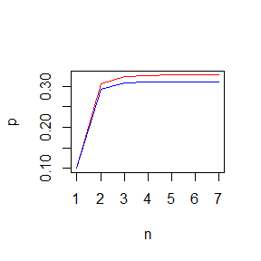

```r
plot(n,p,type="l",col="red")
lines(n,q,col="blue")
```

## Page 204, exercise 3.

Use both for loops and lapply() to fit linear models to the mtcars using the formulas stored in this list:  
formulas <- list(  
mpg ~ disp,  
mpg ~ I(1 / disp),  
mpg ~ disp + wt,  
mpg ~ I(1 / disp) + wt )

## Answer

```r
attach(mtcars)
formulas <- list(
  mpg ~ disp,
  mpg ~ I(1/disp),
  mpg ~ disp + wt,
  mpg ~ I(1 / disp) + wt
)

lapply(formulas,lm,data=mtcars)
```

```
## [[1]]
##
## Call:
## FUN(formula = X[[i]], data = ..1)
##
## Coefficients:
## (Intercept)         disp
##    29.59985     -0.04122
##
##
## [[2]]
##
## Call:
## FUN(formula = X[[i]], data = ..1)
##
## Coefficients:
## (Intercept)    I(1/disp)
##       10.75      1557.67
##
##
## [[3]]
##
## Call:
## FUN(formula = X[[i]], data = ..1)
##
## Coefficients:
## (Intercept)         disp           wt
##    34.96055     -0.01772     -3.35083
##
##
## [[4]]
##
## Call:
## FUN(formula = X[[i]], data = ..1)
##
## Coefficients:
## (Intercept)    I(1/disp)           wt
##      19.024     1142.560       -1.798
```

```r
for(i in 1:4){
  print(lm(formulas[[i]],data=mtcars))
}
```

```
##
## Call:
## lm(formula = formulas[[i]], data = mtcars)
##
## Coefficients:
## (Intercept)         disp
##    29.59985     -0.04122
##
##
## Call:
## lm(formula = formulas[[i]], data = mtcars)
##
## Coefficients:
## (Intercept)    I(1/disp)
##       10.75      1557.67
##
##
## Call:
## lm(formula = formulas[[i]], data = mtcars)
##
## Coefficients:
## (Intercept)         disp           wt
##    34.96055     -0.01772     -3.35083
##
##
## Call:
## lm(formula = formulas[[i]], data = mtcars)
##
## Coefficients:
## (Intercept)    I(1/disp)           wt
##      19.024     1142.560       -1.798
```

## Page 204, exercise 4.

Fit the model mpg ~ disp to each of the bootstrap replicates of mtcars in the list below by using a for loop and lapply(). Can you do it without an anonymous function?  
bootstraps <- lapply(1:10, function(i) {  
rows <- sample(1:nrow(mtcars), rep = TRUE)  
mtcars[rows, ]  
})

## Answer

```r
bootstraps <- lapply(1:10, function(i) {
rows <- sample(1:nrow(mtcars), rep = TRUE)
mtcars[rows, ]
})
lapply(bootstraps,lm,formula=mpg~disp)
```

```
## [[1]]
##
## Call:
## FUN(formula = ..1, data = X[[i]])
##
## Coefficients:
## (Intercept)         disp
##    27.11181     -0.03217
##
##
## [[2]]
##
## Call:
## FUN(formula = ..1, data = X[[i]])
##
## Coefficients:
## (Intercept)         disp
##    30.39595     -0.04571
##
##
## [[3]]
##
## Call:
## FUN(formula = ..1, data = X[[i]])
##
## Coefficients:
## (Intercept)         disp
##    29.17679     -0.03975
##
##
## [[4]]
##
## Call:
## FUN(formula = ..1, data = X[[i]])
##
## Coefficients:
## (Intercept)         disp
##    30.21214     -0.04471
##
##
```

[output cut: 43 more lines]

```
## FUN(formula = ..1, data = X[[i]])
##
## Coefficients:
## (Intercept)         disp
##    31.25076     -0.04947
##
##
## [[10]]
##
## Call:
## FUN(formula = ..1, data = X[[i]])
##
## Coefficients:
## (Intercept)         disp
##    28.01185     -0.03219
```

```r
for(i in 1:10){
  print(lm(mpg ~ disp, data = bootstraps[[i]]) )
}
```

```
##
## Call:
## lm(formula = mpg ~ disp, data = bootstraps[[i]])
##
## Coefficients:
## (Intercept)         disp
##    27.11181     -0.03217
##
##
## Call:
## lm(formula = mpg ~ disp, data = bootstraps[[i]])
##
## Coefficients:
## (Intercept)         disp
##    30.39595     -0.04571
##
##
## Call:
## lm(formula = mpg ~ disp, data = bootstraps[[i]])
##
## Coefficients:
## (Intercept)         disp
##    29.17679     -0.03975
##
##
## Call:
## lm(formula = mpg ~ disp, data = bootstraps[[i]])
##
## Coefficients:
## (Intercept)         disp
##    30.21214     -0.04471
##
##
## Call:
## lm(formula = mpg ~ disp, data = bootstraps[[i]])
##
## Coefficients:
## (Intercept)         disp
##    30.45634     -0.04606
##
```

[output cut: 24 more lines]

```
##
## Call:
## lm(formula = mpg ~ disp, data = bootstraps[[i]])
##
## Coefficients:
## (Intercept)         disp
##    31.25076     -0.04947
##
##
## Call:
## lm(formula = mpg ~ disp, data = bootstraps[[i]])
##
## Coefficients:
## (Intercept)         disp
##    28.01185     -0.03219
```

## Page 204, exercise 5.

5. For each model in the previous two exercises, extract $R^2$ using the function below.  
   rsq <- function(mod) summary(mod)$r.squared

## Answer

```r
attach(mtcars)
rsq <- function(mod) summary(mod)$r.squared
formulas <- list(
  mpg ~ disp,
  mpg ~ I(1/disp),
  mpg ~ disp + wt,
  mpg ~ I(1 / disp) + wt
)
bootstraps <- lapply(1:10, function(i) {
rows <- sample(1:nrow(mtcars), rep = TRUE)
mtcars[rows, ]
})
list1<-lapply(formulas,lm)
list2<-lapply(bootstraps,lm,formula=mpg~disp)
lapply(list1,rsq)
```

```
## [[1]]
## [1] 0.7183433
##
## [[2]]
## [1] 0.8596865
##
## [[3]]
## [1] 0.7809306
##
## [[4]]
## [1] 0.8838038
```

```r
lapply(list2,rsq)
```

```
## [[1]]
## [1] 0.8200983
##
## [[2]]
## [1] 0.7374529
##
## [[3]]
## [1] 0.768726
##
## [[4]]
## [1] 0.8020338
##
## [[5]]
## [1] 0.6487213
##
## [[6]]
## [1] 0.6160471
##
## [[7]]
## [1] 0.7411215
##
## [[8]]
## [1] 0.5997645
##
## [[9]]
## [1] 0.8008671
##
## [[10]]
## [1] 0.6892769
```

## Page 214, exercise 3.

The following code simulates the performance of a t-test for non-normal data. Use sapply() and an anonymous function to extract the p-value from every trial.  
trials <- replicate(100,  
t.test(rpois(10, 10), rpois(7, 10)),  
simplify = FALSE  
) Extra challenge: get rid of the anonymous function by using [[ directly.

## Answer

```r
trials <- replicate(
100,
t.test(rpois(10, 10), rpois(7, 10)),
simplify = FALSE
)
sapply(trials, '[[', 3)
```

```
##   [1] 0.29759697 0.11099574 0.82354358 0.90774980 0.28342476 0.39209973
##   [7] 0.25099892 0.77840644 0.79986291 0.26223248 0.18048724 0.81453722
##  [13] 0.88170344 0.30451133 0.88099329 0.23565541 0.77105421 0.29712687
##  [19] 0.71212953 0.86832090 0.83523260 0.84914073 0.01839931 0.16722271
##  [25] 0.04643680 0.09871941 0.59317834 0.29964795 0.96478883 0.10842009
##  [31] 0.83430948 0.39674073 0.49906278 0.91944320 0.80867968 0.05487791
##  [37] 0.44190793 0.33380539 0.63367000 0.41058724 0.01801381 0.29251919
##  [43] 0.69360198 0.18985681 0.86576453 0.20572082 0.01064783 0.04491611
##  [49] 0.23617775 0.21262534 0.45974588 0.41515832 0.89409618 0.62132513
##  [55] 0.38471754 0.91025343 0.78252123 0.72823469 0.79933959 0.93934399
##  [61] 0.40517731 0.42766197 0.45494458 0.20735171 0.13552085 0.85881294
##  [67] 0.25343313 0.47965324 0.40741880 0.85666251 0.20406126 0.53151976
##  [73] 0.41240597 0.17828586 0.35547250 0.62742498 0.11803681 0.28661647
##  [79] 0.55109880 0.21923066 0.19525159 0.35729123 0.95374145 0.07719677
##  [85] 0.88951940 0.47244567 0.50663837 0.77950044 0.35361797 0.81420996
##  [91] 0.78954666 0.39164962 1.00000000 0.07591689 0.34344393 0.19336802
##  [97] 0.94949456 0.83178793 0.98645134 0.28310117
```

## Page 214, exercise 7.

Implement mcsapply(), a multicore version of sapply(). Can you implement mcvapply(), a parallel version of vapply()? Why or why not?

## Answer

For sapply, just replace ‘lapply’ in the function with ‘mclapply’.

```r
mcsapply<-function(x,f,n){
    f<-match.fun(f)
    answer <- mclapply(x,f,mc.cores=n)
    if (USE.NAMES && is.character(x) && is.null(names(answer)))
        names(answer) <- x
    if (!isFALSE(simplify) && length(answer))
        simplify2array(answer, higher = (simplify == "array"))
    else answer
}
```

For vapply, we cannot implement mcvapply. Because we have to test that the generated results are properly formatted or not. We don’t know how to test them in mc-method. If we can generate the results and test them together in mc-method, then we can implement mcvapply.

## Exercise

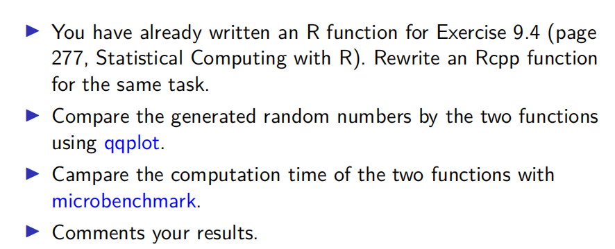

## Answer

```r
library(Rcpp)
library(microbenchmark)
```

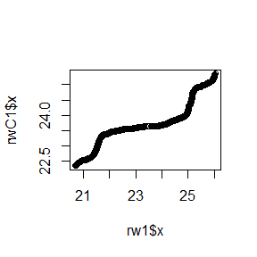

```r
##Rcpp method
cppFunction('List rw_Mc(double x0, double sigma, int N){
NumericVector x(N);
x[0]=x0;
int k=0;
for(int i=1;i<N;i++){

double y=as<double>(rnorm(1,x[i-1], sigma));
double u=as<double>(runif(1));

if (u<=exp(-abs(y))/exp(-abs(x[i-1]))) {
x[i]=y;
k=k+1;
}
else x[i]=x[i-1];
}

return(List::create(Named("x")=x,Named("k")=k));
}')
## R method
rw.M<-function(x0,sigma,N){   ## generate sample for different sigma
  x<-numeric(N)
  x[1]<-x0
  u<-runif(N)
  k<-0
  for(i in 2:N){
    y<-rnorm(1,mean=x[i-1],sd=sigma)
    if(u[i]<=exp(-abs(y))/exp(-abs(x[i-1]))) {
      x[i]<-y
      k<-k+1}
    else x[i]<-x[i-1]
  }
  return(list(x=x,k=k))
}
sigma<-c(0.05,0.5,2,16)
x0<-25
N<-2000
rw1<-rw.M(x0,sigma[1],N)  ## four samples
rw2<-rw.M(x0,sigma[2],N)
rw3<-rw.M(x0,sigma[3],N)
rw4<-rw.M(x0,sigma[4],N)
rwC1<-rw_Mc(x0,sigma[1],N)  ## four samples
rwC2<-rw_Mc(x0,sigma[2],N)
rwC3<-rw_Mc(x0,sigma[3],N)
rwC4<-rw_Mc(x0,sigma[4],N)

##comparison
qqplot(rw1$x,rwC1$x)
```

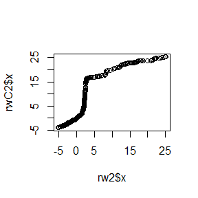

```r
qqplot(rw2$x,rwC2$x)
```

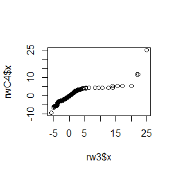

```r
qqplot(rw3$x,rwC4$x)
```

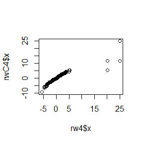

```r
qqplot(rw4$x,rwC4$x)
```

```r
##computation time
ts1<-microbenchmark(rw.M(x0,sigma[1],N),rw_Mc(x0,sigma[1],N))
ts2<-microbenchmark(rw.M(x0,sigma[2],N),rw_Mc(x0,sigma[2],N))
ts3<-microbenchmark(rw.M(x0,sigma[3],N),rw_Mc(x0,sigma[3],N))
ts4<-microbenchmark(rw.M(x0,sigma[4],N),rw_Mc(x0,sigma[4],N))
summary(ts1)[,c(1,3,5,6)]
```

```
##                     expr        lq   median        uq
## 1  rw.M(x0, sigma[1], N) 5655.9480 5895.007 6195.0070
## 2 rw_Mc(x0, sigma[1], N)  568.9955  589.095  605.5595
```

```r
summary(ts2)[,c(1,3,5,6)]
```

```
##                     expr        lq   median       uq
## 1  rw.M(x0, sigma[2], N) 5744.4730 6217.673 7842.119
## 2 rw_Mc(x0, sigma[2], N)  490.5205  515.752  561.298
```

```r
summary(ts3)[,c(1,3,5,6)]
```

```
##                     expr        lq    median        uq
## 1  rw.M(x0, sigma[3], N) 5729.2910 6027.7935 6364.9995
## 2 rw_Mc(x0, sigma[3], N)  516.6075  529.8645  551.2475
```

```r
summary(ts4)[,c(1,3,5,6)]
```

```
##                     expr        lq   median       uq
## 1  rw.M(x0, sigma[4], N) 5661.0800 5862.291 6258.086
## 2 rw_Mc(x0, sigma[4], N)  518.7455  534.783  555.311
```

Hence, we found that Rcpp save much time. The qqplots showed that they are not totally the same, which may be due to the low number of Rcpp acceptances.